# Análisis narrativo de Netflix: revisión, auditoría y limpieza de datos

[Portafolio](https://victormanuelhdez.github.io/portafolio/)

Este notebook trabaja con el dataset **Netflix Titles** y sigue un flujo parecido al notebook del Titanic, pero enfocado en **auditoría, limpieza y análisis exploratorio**.

El objetivo no es crear un modelo predictivo, sino practicar un proceso realista de datos:

- cargar y entender el archivo CSV,
- revisar columnas, tipos y valores faltantes,
- auditar problemas de calidad,
- limpiar datos de forma documentada,
- crear variables nuevas útiles para análisis,
- visualizar patrones principales,
- guardar una versión limpia del dataset.

La idea es que cada paso explique **qué se hace y por qué se hace**.

```python
import pandas as pd
import numpy as np
import matplotlib.pyplot as plt
from pathlib import Path

pd.set_option("display.max_columns", None)
pd.set_option("display.max_colwidth", 120)

plt.rcParams["figure.figsize"] = (9, 5)
plt.rcParams["axes.grid"] = True
```

## 1. Carga de datos

Cada fila representa un título disponible en Netflix. Las columnas principales son:

- `show_id`: identificador del título.
- `type`: tipo de contenido, puede ser `Movie` o `TV Show`.
- `title`: nombre del contenido.
- `director`: director o directores.
- `cast`: reparto principal.
- `country`: país o países relacionados con la producción.
- `date_added`: fecha en que el contenido fue agregado a Netflix.
- `release_year`: año de estreno.
- `rating`: clasificación por edad o audiencia.
- `duration`: duración en minutos para películas o temporadas para series.
- `listed_in`: categorías o géneros.
- `description`: descripción del contenido.

El archivo esperado se llama `netflix_titles.csv`. El código busca el CSV en varias ubicaciones comunes para que sea más fácil correr el notebook.

```python
# Rutas posibles del archivo CSV.
possible_paths = [
    Path("netflix_titles.csv"),
    Path("netflix_titles (1).csv"),
    Path("data/netflix_titles.csv"),
    Path("data/netflix_titles (1).csv"),
    Path("/mnt/data/netflix_titles.csv"),
    Path("/mnt/data/netflix_titles (1).csv"),
]

DATA_PATH = next((path for path in possible_paths if path.exists()), None)

if DATA_PATH is None:
    raise FileNotFoundError(
        "No encontré el archivo netflix_titles.csv. "
        "Colócalo en la misma carpeta del notebook o dentro de una carpeta llamada data."
    )

print("Archivo usado:", DATA_PATH)

df_original = pd.read_csv(DATA_PATH)
print("Filas y columnas originales:", df_original.shape)
df_original.head()
```

```
Archivo usado: /mnt/data/netflix_titles.csv
Filas y columnas originales: (8807, 12)
```

|  | show_id | type | title | director | cast | country | date_added | release_year | rating | duration | listed_in | description |
| --- | --- | --- | --- | --- | --- | --- | --- | --- | --- | --- | --- | --- |
| 0 | s1 | Movie | Dick Johnson Is Dead | Kirsten Johnson | NaN | United States | September 25, 2021 | 2020 | PG-13 | 90 min | Documentaries | As her father nears the end of his life, filmmaker Kirsten Johnson stages his death in inventive and comical ways to... |
| 1 | s2 | TV Show | Blood & Water | NaN | Ama Qamata, Khosi Ngema, Gail Mabalane, Thabang Molaba, Dillon Windvogel, Natasha Thahane, Arno Greeff, Xolile Tshab... | South Africa | September 24, 2021 | 2021 | TV-MA | 2 Seasons | International TV Shows, TV Dramas, TV Mysteries | After crossing paths at a party, a Cape Town teen sets out to prove whether a private-school swimming star is her si... |
| 2 | s3 | TV Show | Ganglands | Julien Leclercq | Sami Bouajila, Tracy Gotoas, Samuel Jouy, Nabiha Akkari, Sofia Lesaffre, Salim Kechiouche, Noureddine Farihi, Geert ... | NaN | September 24, 2021 | 2021 | TV-MA | 1 Season | Crime TV Shows, International TV Shows, TV Action & Adventure | To protect his family from a powerful drug lord, skilled thief Mehdi and his expert team of robbers are pulled into ... |
| 3 | s4 | TV Show | Jailbirds New Orleans | NaN | NaN | NaN | September 24, 2021 | 2021 | TV-MA | 1 Season | Docuseries, Reality TV | Feuds, flirtations and toilet talk go down among the incarcerated women at the Orleans Justice Center in New Orleans... |
| 4 | s5 | TV Show | Kota Factory | NaN | Mayur More, Jitendra Kumar, Ranjan Raj, Alam Khan, Ahsaas Channa, Revathi Pillai, Urvi Singh, Arun Kumar | India | September 24, 2021 | 2021 | TV-MA | 2 Seasons | International TV Shows, Romantic TV Shows, TV Comedies | In a city of coaching centers known to train India’s finest collegiate minds, an earnest but unexceptional student a... |

## 2. Revisión inicial de los datos

Antes de limpiar, conviene responder preguntas básicas:

1. ¿Qué columnas tiene el dataset?
2. ¿Qué tipo de dato tiene cada columna?
3. ¿Cuántos valores faltantes existen?
4. ¿Qué distribución inicial tiene el contenido?

Esta primera revisión ayuda a detectar problemas antes de modificar los datos.

```python
print("Columnas disponibles:")
print(df_original.columns.tolist())

print("\nTipos de datos:")
display(df_original.dtypes.to_frame("tipo"))

print("\nValores faltantes por columna:")
missing = df_original.isna().sum().sort_values(ascending=False)
missing_pct = (missing / len(df_original) * 100).round(2)
display(pd.DataFrame({"faltantes": missing, "porcentaje": missing_pct}))

print("\nResumen numérico:")
display(df_original.describe().T)

print("\nDistribución por tipo de contenido:")
display(df_original["type"].value_counts())

print("\nPrimeras filas:")
display(df_original.head())
```

```
Columnas disponibles:
['show_id', 'type', 'title', 'director', 'cast', 'country', 'date_added', 'release_year', 'rating', 'duration', 'listed_in', 'description']

Tipos de datos:
```

|  | tipo |
| --- | --- |
| show_id | object |
| type | object |
| title | object |
| director | object |
| cast | object |
| country | object |
| date_added | object |
| release_year | int64 |
| rating | object |
| duration | object |
| listed_in | object |
| description | object |

```
Valores faltantes por columna:
```

|  | faltantes | porcentaje |
| --- | --- | --- |
| director | 2634 | 29.91 |
| country | 831 | 9.44 |
| cast | 825 | 9.37 |
| date_added | 10 | 0.11 |
| rating | 4 | 0.05 |
| duration | 3 | 0.03 |
| show_id | 0 | 0.00 |
| type | 0 | 0.00 |
| title | 0 | 0.00 |
| release_year | 0 | 0.00 |
| listed_in | 0 | 0.00 |
| description | 0 | 0.00 |

```
Resumen numérico:
```

|  | count | mean | std | min | 25% | 50% | 75% | max |
| --- | --- | --- | --- | --- | --- | --- | --- | --- |
| release_year | 8807.0 | 2014.180198 | 8.819312 | 1925.0 | 2013.0 | 2017.0 | 2019.0 | 2021.0 |

```
Distribución por tipo de contenido:
```

```
type
Movie      6131
TV Show    2676
Name: count, dtype: int64
```

```
Primeras filas:
```

|  | show_id | type | title | director | cast | country | date_added | release_year | rating | duration | listed_in | description |
| --- | --- | --- | --- | --- | --- | --- | --- | --- | --- | --- | --- | --- |
| 0 | s1 | Movie | Dick Johnson Is Dead | Kirsten Johnson | NaN | United States | September 25, 2021 | 2020 | PG-13 | 90 min | Documentaries | As her father nears the end of his life, filmmaker Kirsten Johnson stages his death in inventive and comical ways to... |
| 1 | s2 | TV Show | Blood & Water | NaN | Ama Qamata, Khosi Ngema, Gail Mabalane, Thabang Molaba, Dillon Windvogel, Natasha Thahane, Arno Greeff, Xolile Tshab... | South Africa | September 24, 2021 | 2021 | TV-MA | 2 Seasons | International TV Shows, TV Dramas, TV Mysteries | After crossing paths at a party, a Cape Town teen sets out to prove whether a private-school swimming star is her si... |
| 2 | s3 | TV Show | Ganglands | Julien Leclercq | Sami Bouajila, Tracy Gotoas, Samuel Jouy, Nabiha Akkari, Sofia Lesaffre, Salim Kechiouche, Noureddine Farihi, Geert ... | NaN | September 24, 2021 | 2021 | TV-MA | 1 Season | Crime TV Shows, International TV Shows, TV Action & Adventure | To protect his family from a powerful drug lord, skilled thief Mehdi and his expert team of robbers are pulled into ... |
| 3 | s4 | TV Show | Jailbirds New Orleans | NaN | NaN | NaN | September 24, 2021 | 2021 | TV-MA | 1 Season | Docuseries, Reality TV | Feuds, flirtations and toilet talk go down among the incarcerated women at the Orleans Justice Center in New Orleans... |
| 4 | s5 | TV Show | Kota Factory | NaN | Mayur More, Jitendra Kumar, Ranjan Raj, Alam Khan, Ahsaas Channa, Revathi Pillai, Urvi Singh, Arun Kumar | India | September 24, 2021 | 2021 | TV-MA | 2 Seasons | International TV Shows, Romantic TV Shows, TV Comedies | In a city of coaching centers known to train India’s finest collegiate minds, an earnest but unexceptional student a... |

## 3. Auditoría de calidad

La auditoría revisa problemas que pueden afectar el análisis:

1. **Duplicados:** filas completas repetidas o identificadores repetidos.
2. **Valores faltantes:** columnas con nulos importantes.
3. **Valores fuera de rango:** años imposibles o duraciones mal registradas.
4. **Consistencia:** columnas donde el contenido no corresponde con su significado.
5. **Cardinalidad:** número de valores únicos por columna.

En este dataset hay un caso importante: algunas filas tienen la duración dentro de `rating`, dejando `duration` vacío. Eso se corrige en la limpieza.

```python
print("--- Auditoría de calidad ---")

# 1) Duplicados.
print("Filas duplicadas exactas:", df_original.duplicated().sum())
print("show_id duplicados:", df_original["show_id"].duplicated().sum())
print("Títulos duplicados:", df_original["title"].duplicated().sum())

# 2) Valores faltantes.
missing_audit = df_original.isna().sum().sort_values(ascending=False)
display(pd.DataFrame({
    "faltantes": missing_audit,
    "porcentaje": (missing_audit / len(df_original) * 100).round(2)
}))

# 3) Años fuera de rango.
print("\nAño mínimo de estreno:", df_original["release_year"].min())
print("Año máximo de estreno:", df_original["release_year"].max())
print("Años menores a 1900:", (df_original["release_year"] < 1900).sum())
print("Años mayores a 2025:", (df_original["release_year"] > 2025).sum())

# 4) Posibles duraciones guardadas por error en rating.
mask_duration_in_rating = (
    df_original["duration"].isna()
    & df_original["rating"].astype(str).str.contains(r"min|Season", case=False, na=False)
)
print("\nFilas con duración posiblemente guardada en rating:", mask_duration_in_rating.sum())
display(df_original.loc[mask_duration_in_rating, ["title", "type", "rating", "duration"]])

# 5) Cardinalidad.
print("\nValores únicos por columna:")
for col in df_original.columns:
    print(f"- {col}: {df_original[col].nunique(dropna=True)}")

print("\nValores únicos en type:")
display(df_original["type"].value_counts(dropna=False))

print("\nValores únicos en rating:")
display(df_original["rating"].value_counts(dropna=False).head(20))
```

```
--- Auditoría de calidad ---
Filas duplicadas exactas: 0
show_id duplicados: 0
Títulos duplicados: 0
```

|  | faltantes | porcentaje |
| --- | --- | --- |
| director | 2634 | 29.91 |
| country | 831 | 9.44 |
| cast | 825 | 9.37 |
| date_added | 10 | 0.11 |
| rating | 4 | 0.05 |
| duration | 3 | 0.03 |
| show_id | 0 | 0.00 |
| type | 0 | 0.00 |
| title | 0 | 0.00 |
| release_year | 0 | 0.00 |
| listed_in | 0 | 0.00 |
| description | 0 | 0.00 |

```
Año mínimo de estreno: 1925
Año máximo de estreno: 2021
Años menores a 1900: 0
Años mayores a 2025: 0

Filas con duración posiblemente guardada en rating: 3
```

|  | title | type | rating | duration |
| --- | --- | --- | --- | --- |
| 5541 | Louis C.K. 2017 | Movie | 74 min | NaN |
| 5794 | Louis C.K.: Hilarious | Movie | 84 min | NaN |
| 5813 | Louis C.K.: Live at the Comedy Store | Movie | 66 min | NaN |

```
Valores únicos por columna:
- show_id: 8807
- type: 2
- title: 8807
- director: 4528
- cast: 7692
- country: 748
- date_added: 1767
- release_year: 74
- rating: 17
- duration: 220
- listed_in: 514
- description: 8775

Valores únicos en type:
```

```
type
Movie      6131
TV Show    2676
Name: count, dtype: int64
```

```
Valores únicos en rating:
```

```
rating
TV-MA       3207
TV-14       2160
TV-PG        863
R            799
PG-13        490
TV-Y7        334
TV-Y         307
PG           287
TV-G         220
NR            80
G             41
TV-Y7-FV       6
NaN            4
NC-17          3
UR             3
66 min         1
74 min         1
84 min         1
Name: count, dtype: int64
```

## 4. Limpieza de datos

Vamos a limpiar una copia del dataset para conservar el original intacto.

### Decisiones de limpieza

1. **Duplicados:** se eliminan filas completamente repetidas si existen.
2. **Texto:** se quitan espacios extra en columnas de tipo texto.
3. **`duration`:** si la duración quedó por error en `rating`, se mueve a `duration`.
4. **`rating`:** los valores faltantes se rellenan con `Sin clasificación`.
5. **`director`, `cast` y `country`:** se reemplazan nulos por etiquetas descriptivas como `No especificado`.
6. **`date_added`:** se convierte a fecha real con `pd.to_datetime`.
7. **`duration`:** se separa en número (`duration_value`) y unidad (`duration_unit`).
8. **Tipos de contenido:** se valida que `type` solo tenga `Movie` o `TV Show`.

Estas decisiones evitan borrar demasiada información y dejan el dataset listo para análisis.

```python
print("--- Iniciando limpieza de datos ---")

df = df_original.copy()
filas_inicio = len(df)

# 1) Eliminar duplicados exactos.
df = df.drop_duplicates().copy()

# 2) Quitar espacios extra en columnas de texto.
text_cols = df.select_dtypes(include="object").columns
for col in text_cols:
    df[col] = df[col].astype("string").str.strip()

# 3) Corregir filas donde la duración quedó en rating.
mask_duration_in_rating = (
    df["duration"].isna()
    & df["rating"].astype("string").str.contains(r"min|Season", case=False, na=False)
)
df.loc[mask_duration_in_rating, "duration"] = df.loc[mask_duration_in_rating, "rating"]
df.loc[mask_duration_in_rating, "rating"] = pd.NA

# 4) Rellenar faltantes categóricos con etiquetas claras.
df["director"] = df["director"].fillna("No especificado")
df["cast"] = df["cast"].fillna("No especificado")
df["country"] = df["country"].fillna("No especificado")
df["rating"] = df["rating"].fillna("Sin clasificación")
df["duration"] = df["duration"].fillna("No especificado")

# 5) Convertir date_added a fecha real.
df["date_added"] = pd.to_datetime(df["date_added"], errors="coerce")

# 6) Extraer número y unidad de duración.
duration_extract = df["duration"].astype("string").str.extract(r"(\d+)\s*(.*)")
df["duration_value"] = pd.to_numeric(duration_extract[0], errors="coerce")
df["duration_unit"] = duration_extract[1].replace("", pd.NA)

# 7) Validar tipo de contenido.
df = df[df["type"].isin(["Movie", "TV Show"])].copy()

filas_final = len(df)

print("Filas iniciales:", filas_inicio)
print("Filas finales:", filas_final)
print("Filas eliminadas:", filas_inicio - filas_final)

print("\nValores faltantes después de la limpieza:")
display(df.isna().sum().sort_values(ascending=False).to_frame("faltantes"))

df.head()
```

```
--- Iniciando limpieza de datos ---
```

```
Filas iniciales: 8807
Filas finales: 8807
Filas eliminadas: 0

Valores faltantes después de la limpieza:
```

|  | faltantes |
| --- | --- |
| date_added | 10 |
| show_id | 0 |
| title | 0 |
| director | 0 |
| cast | 0 |
| type | 0 |
| country | 0 |
| release_year | 0 |
| rating | 0 |
| duration | 0 |
| listed_in | 0 |
| description | 0 |
| duration_value | 0 |
| duration_unit | 0 |

|  | show_id | type | title | director | cast | country | date_added | release_year | rating | duration | listed_in | description | duration_value | duration_unit |
| --- | --- | --- | --- | --- | --- | --- | --- | --- | --- | --- | --- | --- | --- | --- |
| 0 | s1 | Movie | Dick Johnson Is Dead | Kirsten Johnson | No especificado | United States | 2021-09-25 | 2020 | PG-13 | 90 min | Documentaries | As her father nears the end of his life, filmmaker Kirsten Johnson stages his death in inventive and comical ways to... | 90 | min |
| 1 | s2 | TV Show | Blood & Water | No especificado | Ama Qamata, Khosi Ngema, Gail Mabalane, Thabang Molaba, Dillon Windvogel, Natasha Thahane, Arno Greeff, Xolile Tshab... | South Africa | 2021-09-24 | 2021 | TV-MA | 2 Seasons | International TV Shows, TV Dramas, TV Mysteries | After crossing paths at a party, a Cape Town teen sets out to prove whether a private-school swimming star is her si... | 2 | Seasons |
| 2 | s3 | TV Show | Ganglands | Julien Leclercq | Sami Bouajila, Tracy Gotoas, Samuel Jouy, Nabiha Akkari, Sofia Lesaffre, Salim Kechiouche, Noureddine Farihi, Geert ... | No especificado | 2021-09-24 | 2021 | TV-MA | 1 Season | Crime TV Shows, International TV Shows, TV Action & Adventure | To protect his family from a powerful drug lord, skilled thief Mehdi and his expert team of robbers are pulled into ... | 1 | Season |
| 3 | s4 | TV Show | Jailbirds New Orleans | No especificado | No especificado | No especificado | 2021-09-24 | 2021 | TV-MA | 1 Season | Docuseries, Reality TV | Feuds, flirtations and toilet talk go down among the incarcerated women at the Orleans Justice Center in New Orleans... | 1 | Season |
| 4 | s5 | TV Show | Kota Factory | No especificado | Mayur More, Jitendra Kumar, Ranjan Raj, Alam Khan, Ahsaas Channa, Revathi Pillai, Urvi Singh, Arun Kumar | India | 2021-09-24 | 2021 | TV-MA | 2 Seasons | International TV Shows, Romantic TV Shows, TV Comedies | In a city of coaching centers known to train India’s finest collegiate minds, an earnest but unexceptional student a... | 2 | Seasons |

## 5. Creación de variables nuevas

Muchas veces los datos útiles no vienen listos en una sola columna. Aquí creamos variables para analizar mejor el catálogo.

Crearemos:

- `added_year`: año en que el contenido fue agregado a Netflix.
- `added_month`: mes en que fue agregado.
- `main_country`: primer país listado en `country`.
- `main_genre`: primer género listado en `listed_in`.
- `num_genres`: cantidad de categorías asignadas al título.
- `num_cast`: cantidad aproximada de personas listadas en el reparto.
- `is_movie`: indicador de película.
- `is_tv_show`: indicador de serie.
- `movie_minutes`: duración en minutos solo para películas.
- `tv_seasons`: número de temporadas solo para series.
- `years_between_release_and_added`: diferencia entre año de estreno y año agregado a Netflix.

```python
# Año y mes de agregación a Netflix.
df["added_year"] = df["date_added"].dt.year
df["added_month"] = df["date_added"].dt.month

# País principal: primer país de la lista.
df["main_country"] = df["country"].str.split(",").str[0].str.strip()

# Género principal: primer género de la lista.
df["main_genre"] = df["listed_in"].str.split(",").str[0].str.strip()

# Número de géneros por título.
df["num_genres"] = df["listed_in"].str.split(",").apply(lambda x: len(x) if isinstance(x, list) else 0)

# Número aproximado de actores o actrices listados.
df["num_cast"] = df["cast"].apply(
    lambda value: 0 if value == "No especificado" else len(str(value).split(","))
)

# Indicadores por tipo.
df["is_movie"] = (df["type"] == "Movie").astype(int)
df["is_tv_show"] = (df["type"] == "TV Show").astype(int)

# Separar duración de películas y series.
df["movie_minutes"] = np.where(df["type"] == "Movie", df["duration_value"], np.nan)
df["tv_seasons"] = np.where(df["type"] == "TV Show", df["duration_value"], np.nan)

# Diferencia entre estreno y llegada a Netflix.
df["years_between_release_and_added"] = df["added_year"] - df["release_year"]
df.loc[df["years_between_release_and_added"] < 0, "years_between_release_and_added"] = np.nan

print("Nuevas columnas creadas:")
new_cols = [
    "added_year", "added_month", "main_country", "main_genre", "num_genres",
    "num_cast", "is_movie", "is_tv_show", "movie_minutes", "tv_seasons",
    "years_between_release_and_added"
]
print(new_cols)

display(df[new_cols].head())
```

```
Nuevas columnas creadas:
['added_year', 'added_month', 'main_country', 'main_genre', 'num_genres', 'num_cast', 'is_movie', 'is_tv_show', 'movie_minutes', 'tv_seasons', 'years_between_release_and_added']
```

|  | added_year | added_month | main_country | main_genre | num_genres | num_cast | is_movie | is_tv_show | movie_minutes | tv_seasons | years_between_release_and_added |
| --- | --- | --- | --- | --- | --- | --- | --- | --- | --- | --- | --- |
| 0 | 2021.0 | 9.0 | United States | Documentaries | 1 | 0 | 1 | 0 | 90.0 | NaN | 1.0 |
| 1 | 2021.0 | 9.0 | South Africa | International TV Shows | 3 | 19 | 0 | 1 | NaN | 2.0 | 0.0 |
| 2 | 2021.0 | 9.0 | No especificado | Crime TV Shows | 3 | 9 | 0 | 1 | NaN | 1.0 | 0.0 |
| 3 | 2021.0 | 9.0 | No especificado | Docuseries | 2 | 0 | 0 | 1 | NaN | 1.0 | 0.0 |
| 4 | 2021.0 | 9.0 | India | International TV Shows | 3 | 8 | 0 | 1 | NaN | 2.0 | 0.0 |

## 6. Revisión después de la limpieza

Después de limpiar, revisamos si el dataset quedó más consistente.

En esta etapa no buscamos que absolutamente todas las columnas tengan cero nulos, porque algunas fechas pueden no estar disponibles. Lo importante es que los faltantes estén controlados y que las columnas principales sean analizables.

```python
print("Forma final del dataset:", df.shape)

print("\nTipos finales:")
display(df.dtypes.to_frame("tipo"))

print("\nFaltantes finales:")
missing_final = df.isna().sum().sort_values(ascending=False)
display(pd.DataFrame({
    "faltantes": missing_final,
    "porcentaje": (missing_final / len(df) * 100).round(2)
}))

print("\nResumen de películas en minutos:")
display(df["movie_minutes"].describe().to_frame().T)

print("\nResumen de series en temporadas:")
display(df["tv_seasons"].describe().to_frame().T)
```

```
Forma final del dataset: (8807, 25)

Tipos finales:
```

|  | tipo |
| --- | --- |
| show_id | string[python] |
| type | string[python] |
| title | string[python] |
| director | string[python] |
| cast | string[python] |
| country | string[python] |
| date_added | datetime64[ns] |
| release_year | int64 |
| rating | string[python] |
| duration | string[python] |
| listed_in | string[python] |
| description | string[python] |
| duration_value | Int64 |
| duration_unit | string[python] |
| added_year | float64 |
| added_month | float64 |
| main_country | object |
| main_genre | object |
| num_genres | int64 |
| num_cast | int64 |
| is_movie | int64 |
| is_tv_show | int64 |
| movie_minutes | float64 |
| tv_seasons | float64 |
| years_between_release_and_added | float64 |

```
Faltantes finales:
```

|  | faltantes | porcentaje |
| --- | --- | --- |
| tv_seasons | 6131 | 69.62 |
| movie_minutes | 2676 | 30.38 |
| years_between_release_and_added | 24 | 0.27 |
| added_month | 10 | 0.11 |
| added_year | 10 | 0.11 |
| date_added | 10 | 0.11 |
| show_id | 0 | 0.00 |
| director | 0 | 0.00 |
| type | 0 | 0.00 |
| rating | 0 | 0.00 |
| release_year | 0 | 0.00 |
| country | 0 | 0.00 |
| cast | 0 | 0.00 |
| title | 0 | 0.00 |
| duration_value | 0 | 0.00 |
| duration | 0 | 0.00 |
| listed_in | 0 | 0.00 |
| main_country | 0 | 0.00 |
| duration_unit | 0 | 0.00 |
| description | 0 | 0.00 |
| main_genre | 0 | 0.00 |
| is_movie | 0 | 0.00 |
| num_cast | 0 | 0.00 |
| num_genres | 0 | 0.00 |
| is_tv_show | 0 | 0.00 |

```
Resumen de películas en minutos:
```

|  | count | mean | std | min | 25% | 50% | 75% | max |
| --- | --- | --- | --- | --- | --- | --- | --- | --- |
| movie_minutes | 6131.0 | 99.564998 | 28.289504 | 3.0 | 87.0 | 98.0 | 114.0 | 312.0 |

```
Resumen de series en temporadas:
```

|  | count | mean | std | min | 25% | 50% | 75% | max |
| --- | --- | --- | --- | --- | --- | --- | --- | --- |
| tv_seasons | 2676.0 | 1.764948 | 1.582752 | 1.0 | 1.0 | 1.0 | 2.0 | 17.0 |

## 7. Visualizaciones exploratorias

Las visualizaciones ayudan a ver patrones de forma rápida.

Observaremos:

- distribución entre películas y series,
- años con más contenido agregado,
- países principales con más títulos,
- géneros principales más frecuentes,
- distribución de duración en películas,
- temporadas más comunes en series.

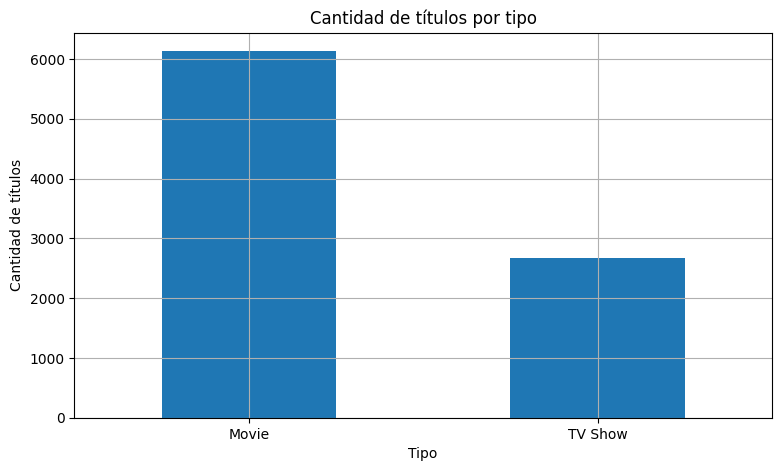

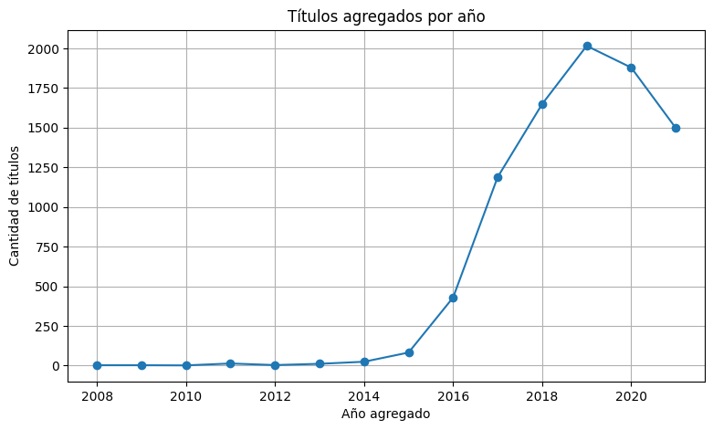

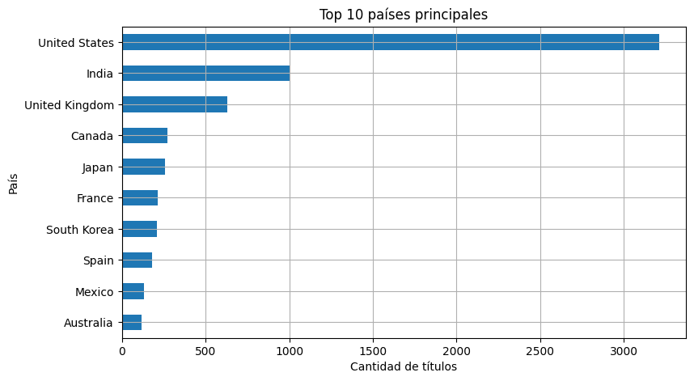

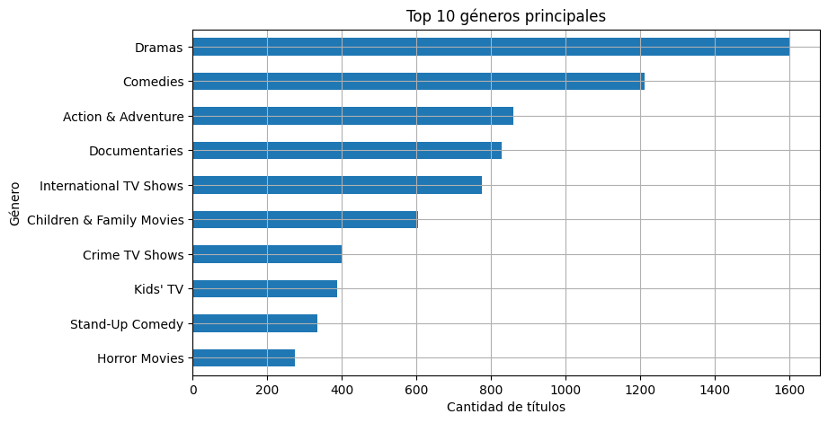

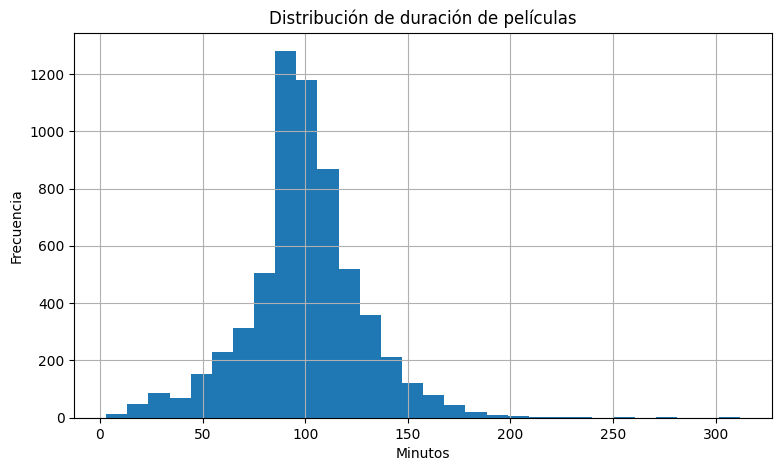

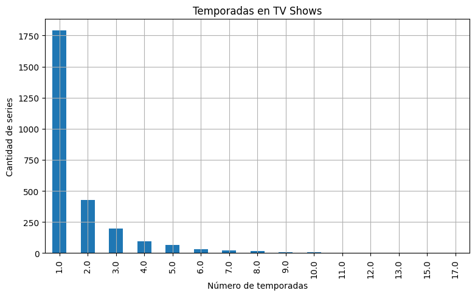

```python
# 1) Tipo de contenido.
type_counts = df["type"].value_counts()
type_counts.plot(kind="bar", title="Cantidad de títulos por tipo")
plt.xlabel("Tipo")
plt.ylabel("Cantidad de títulos")
plt.xticks(rotation=0)
plt.show()

# 2) Año en que se agregó contenido a Netflix.
added_by_year = df["added_year"].dropna().astype(int).value_counts().sort_index()
added_by_year.plot(kind="line", marker="o", title="Títulos agregados por año")
plt.xlabel("Año agregado")
plt.ylabel("Cantidad de títulos")
plt.show()

# 3) Países principales.
top_countries = df[df["main_country"] != "No especificado"]["main_country"].value_counts().head(10)
top_countries.sort_values().plot(kind="barh", title="Top 10 países principales")
plt.xlabel("Cantidad de títulos")
plt.ylabel("País")
plt.show()

# 4) Géneros principales.
top_genres = df["main_genre"].value_counts().head(10)
top_genres.sort_values().plot(kind="barh", title="Top 10 géneros principales")
plt.xlabel("Cantidad de títulos")
plt.ylabel("Género")
plt.show()

# 5) Duración de películas.
df["movie_minutes"].dropna().plot(kind="hist", bins=30, title="Distribución de duración de películas")
plt.xlabel("Minutos")
plt.ylabel("Frecuencia")
plt.show()

# 6) Temporadas en series.
df["tv_seasons"].dropna().value_counts().sort_index().plot(kind="bar", title="Temporadas en TV Shows")
plt.xlabel("Número de temporadas")
plt.ylabel("Cantidad de series")
plt.show()
```

## 8. Tablas de análisis

Además de las gráficas, las tablas resumen ayudan a responder preguntas concretas.

```python
print("Contenido por tipo:")
display(df["type"].value_counts().to_frame("cantidad"))

print("\nTop 10 países principales:")
display(df[df["main_country"] != "No especificado"]["main_country"].value_counts().head(10).to_frame("cantidad"))

print("\nTop 10 géneros principales:")
display(df["main_genre"].value_counts().head(10).to_frame("cantidad"))

print("\nClasificaciones más frecuentes:")
display(df["rating"].value_counts().head(10).to_frame("cantidad"))

print("\nDuración promedio de películas por género principal:")
display(
    df.dropna(subset=["movie_minutes"])
      .groupby("main_genre")["movie_minutes"]
      .agg(["count", "mean", "median"])
      .sort_values("count", ascending=False)
      .head(10)
      .round(2)
)

print("\nTemporadas promedio de series por género principal:")
display(
    df.dropna(subset=["tv_seasons"])
      .groupby("main_genre")["tv_seasons"]
      .agg(["count", "mean", "median"])
      .sort_values("count", ascending=False)
      .head(10)
      .round(2)
)
```

```
Contenido por tipo:
```

| type | cantidad |
| --- | --- |
| Movie | 6131 |
| TV Show | 2676 |

```
Top 10 países principales:
```

| main_country | cantidad |
| --- | --- |
| United States | 3211 |
| India | 1008 |
| United Kingdom | 628 |
| Canada | 271 |
| Japan | 259 |
| France | 212 |
| South Korea | 211 |
| Spain | 181 |
| Mexico | 134 |
| Australia | 117 |

```
Top 10 géneros principales:
```

| main_genre | cantidad |
| --- | --- |
| Dramas | 1600 |
| Comedies | 1210 |
| Action & Adventure | 859 |
| Documentaries | 829 |
| International TV Shows | 774 |
| Children & Family Movies | 605 |
| Crime TV Shows | 399 |
| Kids' TV | 388 |
| Stand-Up Comedy | 334 |
| Horror Movies | 275 |

```
Clasificaciones más frecuentes:
```

| rating | cantidad |
| --- | --- |
| TV-MA | 3207 |
| TV-14 | 2160 |
| TV-PG | 863 |
| R | 799 |
| PG-13 | 490 |
| TV-Y7 | 334 |
| TV-Y | 307 |
| PG | 287 |
| TV-G | 220 |
| NR | 80 |

```
Duración promedio de películas por género principal:
```

| main_genre | count | mean | median |
| --- | --- | --- | --- |
| Dramas | 1600 | 111.38 | 108.0 |
| Comedies | 1210 | 106.69 | 102.0 |
| Action & Adventure | 859 | 113.52 | 108.0 |
| Documentaries | 829 | 82.15 | 87.0 |
| Children & Family Movies | 605 | 78.43 | 86.0 |
| Stand-Up Comedy | 334 | 66.91 | 65.0 |
| Horror Movies | 275 | 98.17 | 94.0 |
| International Movies | 128 | 108.06 | 107.0 |
| Classic Movies | 80 | 114.82 | 112.0 |
| Thrillers | 65 | 99.95 | 97.0 |

```
Temporadas promedio de series por género principal:
```

| main_genre | count | mean | median |
| --- | --- | --- | --- |
| International TV Shows | 774 | 1.34 | 1.0 |
| Crime TV Shows | 399 | 1.71 | 1.0 |
| Kids' TV | 388 | 1.99 | 2.0 |
| British TV Shows | 253 | 1.82 | 1.0 |
| Docuseries | 221 | 1.37 | 1.0 |
| Anime Series | 176 | 1.57 | 1.0 |
| Reality TV | 120 | 1.49 | 1.0 |
| TV Comedies | 120 | 3.02 | 2.0 |
| TV Dramas | 67 | 2.87 | 2.0 |
| TV Action & Adventure | 40 | 2.95 | 2.0 |

## 9. Guardar dataset limpio

Finalmente guardamos una copia limpia para poder usarla en otro análisis, dashboard o entrega.

El archivo se llamará `netflix_titles_limpio.csv`.

```python
OUTPUT_PATH = Path("netflix_titles_limpio.csv")
df.to_csv(OUTPUT_PATH, index=False)

print("Archivo limpio guardado en:", OUTPUT_PATH.resolve())
print("Filas y columnas guardadas:", df.shape)
```

```
Archivo limpio guardado en: /netflix_titles_limpio.csv
Filas y columnas guardadas: (8807, 25)
```

## 10. Conclusiones

Después de la auditoría y limpieza se puede concluir que:

1. El dataset original tenía valores faltantes principalmente en `director`, `cast`, `country`, `date_added`, `rating` y `duration`.
2. No todos los faltantes debían eliminarse; en columnas como `director`, `cast` y `country` era mejor usar una etiqueta como `No especificado`.
3. La columna `date_added` necesitaba convertirse a formato de fecha para poder analizar años y meses.
4. La columna `duration` contenía dos tipos de información: minutos para películas y temporadas para series. Por eso se separó en variables nuevas.
5. Se crearon columnas como `main_country`, `main_genre`, `movie_minutes` y `tv_seasons`, que permiten hacer análisis más claros.
6. La mayoría del catálogo está compuesto por películas, aunque también hay una cantidad importante de series.
7. Estados Unidos, India y Reino Unido suelen aparecer entre los países principales con más títulos.
8. Los géneros más frecuentes permiten entender mejor el enfoque del catálogo.

Este flujo muestra una parte esencial del trabajo con datos: antes de analizar o graficar, primero hay que revisar, auditar y limpiar.